# Empowering Women with Self-defense Skills using R

## Empowering Women with Self-defense Skills using R

## The Instructors

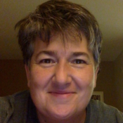

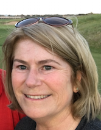

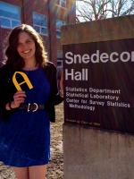

Heike Hofmann  
Professor  
Department of Statistics  
Iowa State University

Dianne Cook  
Professor  
Department of Econometrics and Business Statistics Monash University

Sam Tyner  
PhD Candidate  
Department of Statistics  
Iowa State University

## Plan for the Workshop

1. Scraping polling data
2. genderizer package/API
3. Female authors of R packages

## Follow along

All Resources are available from GitHub at https://github.com/dicook/WSDS-selfdefense

- Download the repo (zip or download to desktop)
- Double-click the R project `WSDS-selfdefense.Rproj`
- `slides.Rmd` contains this set of slides (and the code)
- Do you have the newest version of R? some packages we use need `R 3.3.1`

## Scraping the web

## An Example

The website RealClearPolitics tracks poll results for this presidential election

Polls of Clinton versus Trump at the national level available at http://www.realclearpolitics.com/epolls/2016/president/us/general_election_trump_vs_clinton-5491.html

[figure not shown]

## The Goal of this exercise is to

- get the polls from the RCP website
- clean the data
- visualize it

## Scraping the data

- resources used: `rvest` and `xml2` packages
- general code idea:

[output not shown]

`tables` consists of a list of all tables at the specified URL

## RCP national polls

```r
url <- "http://www.realclearpolitics.com/epolls/2016/president/us/general_election_trump_vs_clinton-5491.html"
doc <- xml2::read_html(url)
tables <- rvest::html_table(doc)
tables %>% purrr::map(.f = dim)
```

```
## [[1]]
## [1] 11  7
##
## [[2]]
## [1] 2 1
##
## [[3]]
## [1] 1 2
##
## [[4]]
## [1] 225   7
```

## Raw data

```r
raw <- tables[[4]]
tail(raw)
```

```
##                            Poll        Date  Sample MoE Clinton (D)
## 220 CNN/Opinion ResearchCNN/ORC 7/22 - 7/25  898 RV 3.5          56
## 221              PPP (D)PPP (D) 7/20 - 7/21 1087 RV 3.0          50
## 222  USA Today/SuffolkUSA Today  7/9 - 7/12 1000 LV 3.0          51
## 223 CNN/Opinion ResearchCNN/ORC 6/26 - 6/28  890 RV 3.5          59
## 224            FOX NewsFOX News 6/21 - 6/23 1005 RV 3.0          51
## 225        QuinnipiacQuinnipiac 5/19 - 5/26 1711 RV 2.4          50
##     Trump (R)      Spread
## 220        40 Clinton +16
## 221        37 Clinton +13
## 222        34 Clinton +17
## 223        35 Clinton +24
## 224        34 Clinton +17
## 225        32 Clinton +18
```

First impressions: 225 polls dating back to May … but that's May 2015!

## Data Cleaning Checklist

- the poll names in `Poll` are strange
- the dates in `Date` need to be separated into a start date and end date
- the variable `Sample` consists of two pieces of information: the number of participants and the type of voters
- the variable `Spread` consists of multiple pieces, but that doesn't matter
- rename variables: Clinton (D) and Trump (R) to Clinton and Trump
- we need to convert the date variables into actual dates
- use only the first 118 poll results (all polls since July 2016)
- the first value is `RCP Average` - that's not a poll

## Data Cleaning (1)

- the dates in `Date` need to be separated into a start date and end date

```
separate <- function (data, col, into, sep = "[^[:alnum:]]+", remove = TRUE,
    convert = FALSE, extra = "warn", fill = "warn", ...)
```

```r
library(tidyr)
polls <- raw %>% separate(Date, into = c("Start_Date", "End_Date"), sep = " - ")
glimpse(polls)
```

```
## Observations: 225
## Variables: 8
## $ Poll        <chr> "RCP Average", "IBD/TIPP TrackingIBD/TIPP Tracking...
## $ Start_Date  <chr> "10/10", "10/16", "10/15", "10/17", "10/15", "10/1...
## $ End_Date    <chr> "10/21", "10/21", "10/20", "10/18", "10/21", "10/2...
## $ Sample      <chr> "--", "791 LV", "779 LV", "1007 LV", "3052 LV", "3...
## $ MoE         <chr> "--", "3.6", "3.6", "3.1", "4.5", "4.5", "3.9", "3...
## $ Clinton (D) <dbl> 48, 42, 43, 50, 44, 44, 47, 49, 50, 43, 53, 51, 51...
## $ Trump (R)   <dbl> 41.9, 42.0, 41.0, 44.0, 44.0, 45.0, 43.0, 42.0, 41...
## $ Spread      <chr> "Clinton +6.1", "Tie", "Clinton +2", "Clinton +6",...
```

## Data Cleaning (2)

- Convert the date information into a date type (POSIXct)
- Use only polls since July 2016

```r
library(lubridate)
polls <- raw[1:119, ] %>%
  separate(Date, into = c("Start_Date", "End_Date"), sep = " - ") %>%
  mutate(
    Start_Date = ymd(paste("2016", Start_Date, sep = "/")),
    End_Date = ymd(paste("2016", End_Date, sep = "/"))
  )

str(polls)
```

```
## 'data.frame':    119 obs. of  8 variables:
##  $ Poll       : chr  "RCP Average" "IBD/TIPP TrackingIBD/TIPP Tracking" "IBD/TIPP TrackingIBD/TIPP Tracking" "QuinnipiacQuinnipiac" ...
##  $ Start_Date : Date, format: "2016-10-10" "2016-10-16" ...
##  $ End_Date   : Date, format: "2016-10-21" "2016-10-21" ...
##  $ Sample     : chr  "--" "791 LV" "779 LV" "1007 LV" ...
##  $ MoE        : chr  "--" "3.6" "3.6" "3.1" ...
##  $ Clinton (D): num  48 42 43 50 44 44 47 49 50 43 ...
##  $ Trump (R)  : num  41.9 42 41 44 44 45 43 42 41 39 ...
##  $ Spread     : chr  "Clinton +6.1" "Tie" "Clinton +2" "Clinton +6" ...
```

## Data Cleaning (3)

- Separate the variable `Sample` into two pieces of information
- Convert `Number` to a numeric variable
- Remove first record

```r
polls <- polls %>%
  separate(Sample, into = c("Number", "Type")) %>%
  mutate(
    Number = as.numeric(Number)
  ) %>% filter(Poll != "RCP Average")
names(polls)[7:8] <- c("Clinton", "Trump")

str(polls)
```

```
## 'data.frame':    118 obs. of  9 variables:
##  $ Poll      : chr  "IBD/TIPP TrackingIBD/TIPP Tracking" "IBD/TIPP TrackingIBD/TIPP Tracking" "QuinnipiacQuinnipiac" "LA Times/USC TrackingLA Times" ...
##  $ Start_Date: Date, format: "2016-10-16" "2016-10-15" ...
##  $ End_Date  : Date, format: "2016-10-21" "2016-10-20" ...
##  $ Number    : num  791 779 1007 3052 3001 ...
##  $ Type      : chr  "LV" "LV" "LV" "LV" ...
##  $ MoE       : chr  "3.6" "3.6" "3.1" "4.5" ...
##  $ Clinton   : num  42 43 50 44 44 47 49 50 43 53 ...
##  $ Trump     : num  42 41 44 44 45 43 42 41 39 41 ...
##  $ Spread    : chr  "Tie" "Clinton +2" "Clinton +6" "Tie" ...
```

```r
write.csv(polls, file= "data/polls.csv", row.names=FALSE)
```

## Data cleaning recap

- Getting the data was much easier than cleaning it
- Generalization of data cleaning not possible
- Cleaning poll names out of reach for now
- Resources for cleaning: `lubridate` (dates and times), `tidyr` (data wrangling), `dplyr` (data flow)

… and we are not done yet!

Nest steps:

- combine all pollsters with fewer than five polls into `Other`

## Data Cleaning (4)

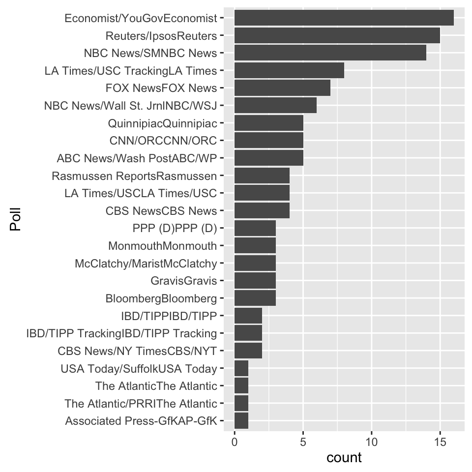

```r
library(ggplot2)
polls <- polls %>% mutate(
    Poll = reorder(Poll, Poll, length)
  )
polls %>%
  ggplot(aes(Poll)) + geom_bar() + coord_flip()
```

## Data Cleaning (5)

- combine all pollsters with fewer than five polls into `Other`

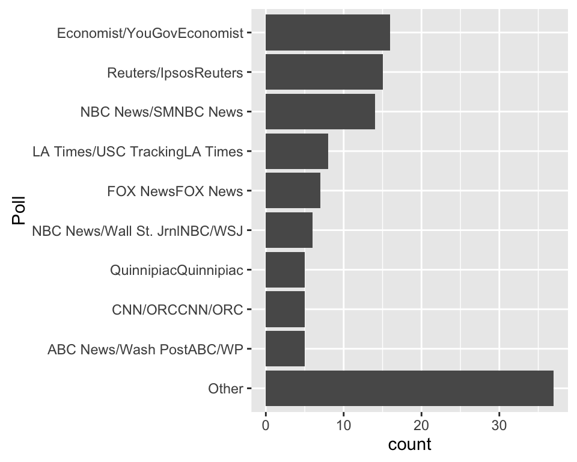

```r
levels(polls$Poll)[1:15] <- "Other"

polls %>%
  ggplot(aes(Poll)) + geom_bar() + coord_flip()
```

## Visualization

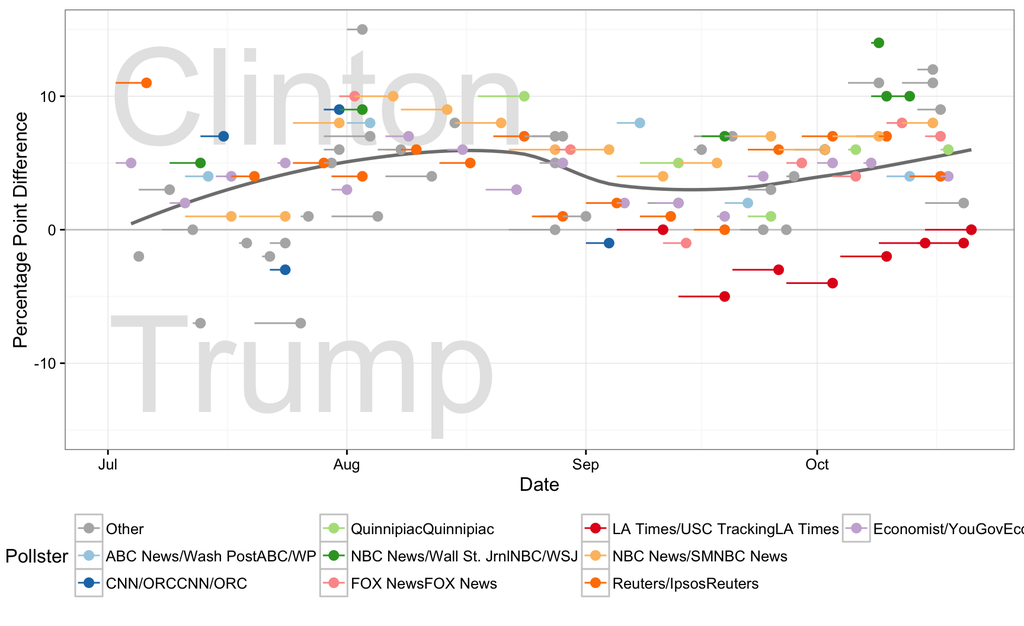

## Code for Visualization

```
library(ggplot2)
brewer_cols <- RColorBrewer::brewer.pal(9, "Paired") # only palette with nine values without grey

polls %>%
  ggplot(aes(x = End_Date, y = Clinton - Trump)) +
    annotate("text", x = ymd("2016/07/1"), y = 10, label = "Clinton",
             size = 30, colour = "grey90", hjust=0) +
    annotate("text", x = ymd("2016/07/1"), y = -10, label = "Trump",
             size = 30, colour = "grey90", hjust=0) +
    geom_hline(yintercept = 0, colour = "grey80") +
    geom_smooth(se = FALSE, colour = "grey50") +
    geom_point(aes(colour = Poll), size = 2.5) +
    geom_segment(aes(colour = Poll, yend = Clinton - Trump, xend = Start_Date)) +
    theme_bw() +
    theme(legend.position = "bottom") +
    scale_colour_manual("Pollster", values = c("grey70", brewer_cols),
                        guide = guide_legend(nrow = 3)) +
  ylim(c(-15, 15)) +
  ylab("Percentage Point Difference") +
  xlab("Date")
```

## Visualization Recap

- there is huge variability in polls and between pollsters
- house bias of some pollsters is enormous (cf. LA Times versus NBC News)

## Your Turn

## Exercise

- RealClearPolitics shows all state-level poll results from last week at http://www.realclearpolitics.com/epolls/latest_polls/state/
- Read the data from the website
- Identify the data format
- Make a plan for processing the data
- Start working on this process for one of the data sets
- Assess the possibility of automating the process (i.e. write function, use repeatedly)

## Alternate Exercise

- Do you have an idea on how to fix the Poll names?

```r
levels(polls$Poll)
```

```
##  [1] "Other"                         "ABC News/Wash PostABC/WP"
##  [3] "CNN/ORCCNN/ORC"                "QuinnipiacQuinnipiac"
##  [5] "NBC News/Wall St. JrnlNBC/WSJ" "FOX NewsFOX News"
##  [7] "LA Times/USC TrackingLA Times" "NBC News/SMNBC News"
##  [9] "Reuters/IpsosReuters"          "Economist/YouGovEconomist"
```

## genderize

[figure not shown]

## `genderizeR` package

Kamil Wais (2016). genderizeR: Gender Prediction Based on First Names. R package version 2.0.0. https://CRAN.R-project.org/package=genderizeR

```r
library(genderizeR)

givenNames <- findGivenNames(c("heike", "di", "sam", "samantha", "jiayang", "bin", "german", "christian"))
```

```r
givenNames
```

```
##         name gender probability count
## 1:       bin   male        0.89    37
## 2: christian   male        0.99  2548
## 3:        di female        0.81   176
## 4:    german   male        1.00   405
## 5:     heike female        0.98    48
## 6:       sam   male        0.76  3336
## 7:  samantha female        1.00  2438
```

- results from findGivenNames build database to be used in `genderize` function
- genderize.io API restricts to at most free 1000 checks a day
- genderize.io allows for country specification, but `findGivenNames` doesn't support that yet

## R package authors

## Collect the list from RStudio's CRAN mirror

- Download package details from http://cran.rstudio.com//web/packages/packages.rds

```r
db <- readRDS("data/packages.rds")
glimpse(db)
```

```
##  chr [1:9380, 1:65] "A3" "abbyyR" "abc" "ABCanalysis" ...
##  - attr(*, "dimnames")=List of 2
##   ..$ : NULL
##   ..$ : chr [1:65] "Package" "Version" "Priority" "Depends" ...
##  - attr(*, "web_dir")= chr "/srv/ftp/pub/R/web/packages"
##  - attr(*, "src_dir")= chr "/srv/ftp/pub/R/src/contrib"
```

## Clean up

```r
clean_up <- function(x){
  # get rid of punctuation
  x1 <- gsub("[[:punct:]]", " ", x)
  # remove leading space before first name
  x2 <- str_trim(x1 , side="left")
  # get first name only
  x3 <- unlist(lapply(x2, first.word))
  # gender function only takes lower case
  x4 <- tolower(x3)
  return(x4)
}
```

```r
maintainer_year_unclean <- data.frame(db) %>% transmute(
    name = Maintainer,
    year = as.integer(substr(Published, 1, 4)),
    author = Author,
    title = Title
  )
maintainer_year_clean <- maintainer_year_unclean
maintainer_year_clean$firstname <- clean_up(maintainer_year_clean$name)
```

```r
glimpse(maintainer_year_clean)
```

```
## Observations: 9,380
## Variables: 5
## $ name      <fctr> Scott Fortmann-Roe <scottfr@berkeley.edu>, Gaurav S...
## $ year      <int> 2015, 2016, 2015, 2016, 2015, 2012, 2013, 2016, 2016...
## $ author    <fctr> Scott Fortmann-Roe, Gaurav Sood [aut, cre], Csiller...
## $ title     <fctr> Accurate, Adaptable, and Accessible Error Metrics f...
## $ firstname <chr> "scott", "gaurav", "blum", "michael", "blum", "abhil...
```

## Manually edited name list

- First names of maintainers of R packages, genderized in March 2016
- Manually edited to give some guesses for non-European names

```r
genderized_names <- read_csv("data/all_names_manual.csv")
maintainer_year_clean <- left_join(maintainer_year_clean,
                                   genderized_names, by="firstname")
glimpse(maintainer_year_clean)
```

```
## Observations: 9,380
## Variables: 10
## $ name        <fctr> Scott Fortmann-Roe <scottfr@berkeley.edu>, Gaurav...
## $ year        <int> 2015, 2016, 2015, 2016, 2015, 2012, 2013, 2016, 20...
## $ author      <fctr> Scott Fortmann-Roe, Gaurav Sood [aut, cre], Csill...
## $ title       <fctr> Accurate, Adaptable, and Accessible Error Metrics...
## $ firstname   <chr> "scott", "gaurav", "blum", "michael", "blum", "abh...
## $ freq        <int> 55, 5, 2, 124, 2, 1, 11, NA, NA, 13, 21, 25, 36, 3...
## $ gender      <chr> "male", "male", "male", "male", "male", "male", "m...
## $ probability <dbl> 1.00, 1.00, NA, 1.00, NA, 1.00, 0.99, NA, NA, 0.53...
## $ count       <int> 3450, 241, NA, 11160, NA, 33, 2098, NA, NA, 1523, ...
## $ guess       <chr> "no", "no", "yes", "no", "yes", "no", "no", NA, NA...
```

## Create summaries

```r
maintainer_year_clean %>% group_by(gender) %>% tally()
```

```
## # A tibble: 3 × 2
##   gender     n
##    <chr> <int>
## 1 female  1271
## 2   male  7527
## 3   <NA>   582
```

## Plot counts

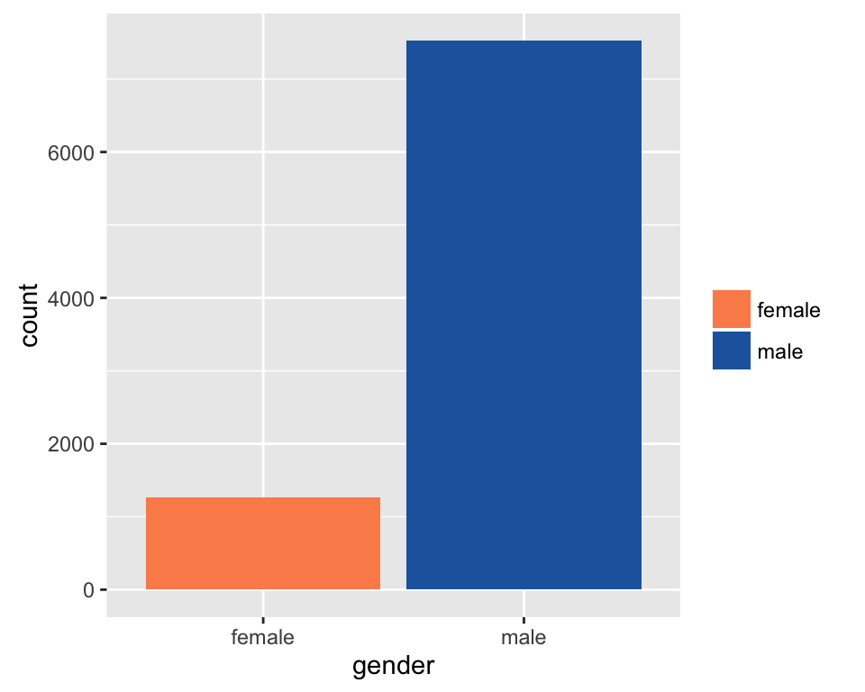

```r
ggplot(maintainer_year_clean, aes(x=gender, fill=gender)) +
  geom_bar() +
  scale_fill_manual("", values=c("female"="#fc8d59", "male"="#2166ac"),
                    na.value="white")
```

## By year

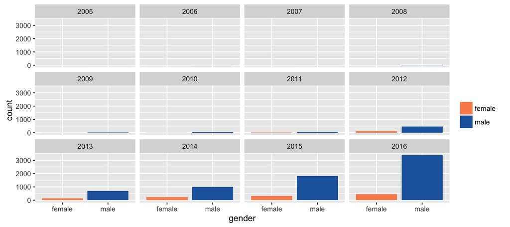

```r
ggplot(maintainer_year_clean, aes(x=gender, fill=gender)) +
  geom_bar() +
  scale_fill_manual("", values=c("female"="#fc8d59", "male"="#2166ac"),
                    na.value="white") +
  facet_wrap(~year)
```

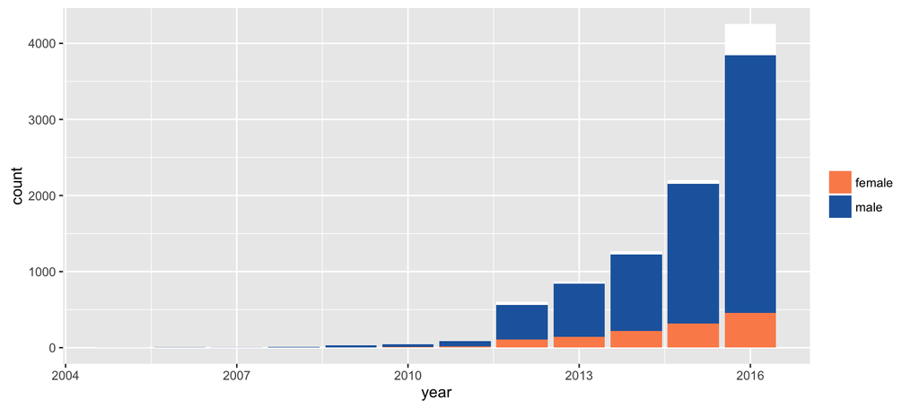

```r
ggplot(maintainer_year_clean, aes(x=year, fill=gender)) +
  geom_bar() +
  scale_fill_manual("", values=c("female"="#fc8d59", "male"="#2166ac"),
                    na.value="white")
```

## Focus on proportions

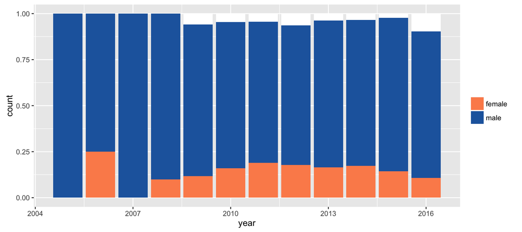

```r
ggplot(maintainer_year_clean, aes(x=year, fill=gender)) +
  geom_bar(position = "fill") +
  scale_fill_manual("", values=c("female"="#fc8d59", "male"="#2166ac"),
                    na.value="white")
```

## Your Turn

## Exercise

- Extract the author first names from the R package details
- Match the names to gender
- Make some summaries of the gender statistics

## That's all

Happy hacking!!